# 140.651 - Lab 3

### HW1 - Problem 12

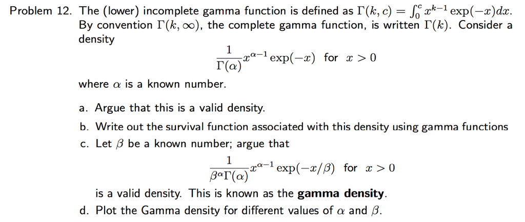

- 1. A valid density $f(x)$ should satisfy two conditions: 1). $f(x)\geq 0$ for all $x$. 2). $\int_{-\infty}^{\infty}f(x)dx=1$. [*Reference: Lecture 2, slide 26/43 - “PDF”*]
  - $f(x)=\frac{1}{\Gamma(\alpha)}x^{\alpha-1}\exp(-x)\geq 0$ for $x>0$.
  - $\int_{-\infty}^{\infty}f(x)dx=\frac{1}{\Gamma(\alpha)}\int_0^{\infty}x^{\alpha-1}\exp(-x)=\frac{1}{\Gamma(\alpha)}\Gamma(\alpha)=1$.
- 2. $S(t)=1-F(t)$. Integrate the density from 0 to $t$ to compute $F(t)$: $F(t) = \int_{-\infty}^tf(x)dx.$
- 3. This function is greater than 0. To show that it integrates to 1, we use the change of variable formula $y=x/\beta$:
  - $\int_0^{\infty}\frac{1}{\beta^{\alpha}\Gamma(\alpha)}x^{\alpha-1}\exp(-x/\beta)=\frac{1}{\beta^{\alpha}\Gamma(\alpha)}\int_0^{\infty}(\beta y)^{\alpha-1}\exp(-y)\beta dy=1$.
- 4. The `dgamma()` function returns the density of gamma distribution.

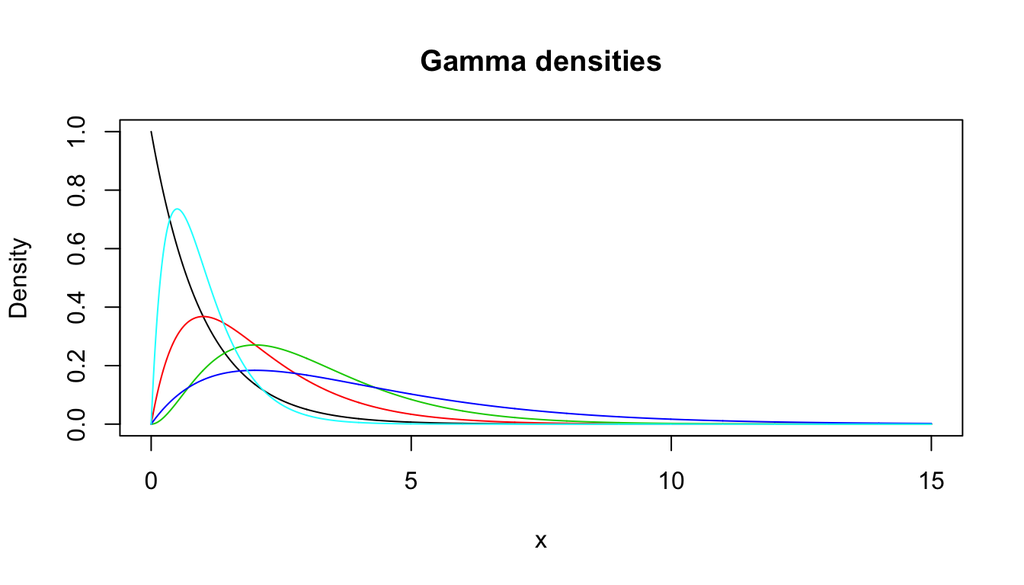

```r
x <- seq(from = 0, to = 15, by = 0.01)
y1 <- dgamma(x, shape=1, scale=1)
y2 <- dgamma(x, shape=2, scale=1)
y3 <- dgamma(x, shape=3, scale=1)
y4 <- dgamma(x, shape=2, scale=2)
y5 <- dgamma(x, shape=2, scale=0.5)

plot(x, y1, main = "Gamma densities", xlab = "x", ylab = "Density", type = "l")
lines(x, y2, col=2)
lines(x, y3, col=3)
lines(x, y4, col=4)
lines(x, y5, col=5)
```

### HW1 - Problem 13

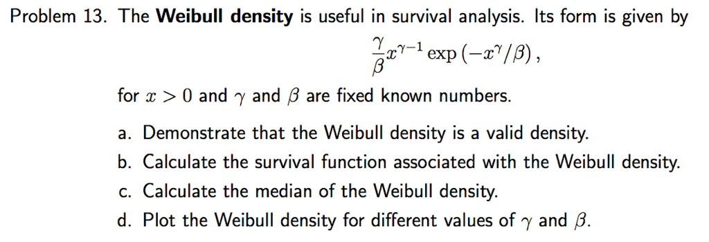

### HW1 - Problem 9

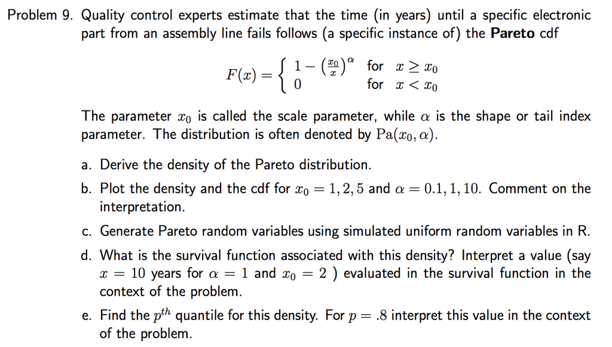

##### (a)

We can recover PDF from CDF via $f ( x ) = F ^ { \prime } ( x )$.
$$\frac{d}{dx} \left(1 - \left( \frac { x _ { 0 } } { x } \right) ^ { \alpha } \right) =
\frac{d}{dx} \left(1 - x_0^{\alpha} x ^{-\alpha} \right) = \alpha x_0^{\alpha} x ^{-\alpha-1}$$
Hence $f(x) = \alpha x_0^{\alpha} x ^{-\alpha-1}$ for $x\geq x_0$ and $0$ for $x < x_0$.

##### (b)

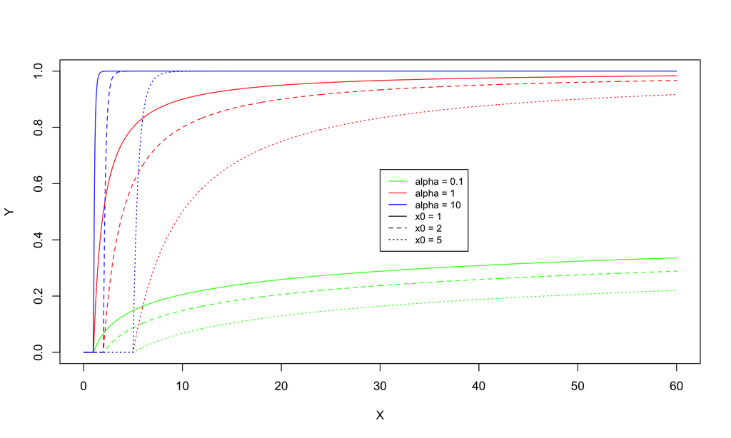

```r
## Function to compute CDF of Pareto
cdf <- function(x0, xs, alph){
  cd <- 1 - (x0/xs)^alph
  cd[xs <= x0] <- 0
  return(cd)
}

## Parameters and variables
x0s <- c(1, 2, 5)
as <- c(0.1, 1, 10)
xs <- seq(0, 60, length = 1000)
dat <- expand.grid(x0 = x0s, alpha = as)
dat$lty <- rep(c("solid", "dashed", "dotted"), 3)
dat$col <- c(rep("green", 3), rep("red", 3), rep("blue", 3))

## Plot
plot(xs, rep(0, 1000), type = "n", ylim = c(0, 1),  xlab = "X", ylab = "Y")
for (irow in 1:nrow(dat)) {
  lines(xs, cdf(dat$x0[irow], xs, dat$alpha[irow]),
        lty = dat$lty[irow], col = dat$col[irow])
}
legend(x = 30, y = 0.65, legend = c("alpha = 0.1", "alpha = 1", "alpha = 10",
      "x0 = 1", "x0 = 2", "x0 = 5"), col = c("green", "red", "blue", "black",
      "black", "black"), lty = c("solid", "solid", "solid", "solid", "dashed",
      "dotted"), cex = 0.8)
```

##### (c)

If $u$ is a uniform random number on $[0,1]$, then $x = F^{-1}(u)$ generates a random number $x$ from any continuous distribution with the specified cdf $F$.

$$u \overset{set}{=} F ( x ) = 1 - \left( \frac { x _ { 0 } } { x } \right) ^ { \alpha }$$
$$\Rightarrow x = \frac { x _ { 0 } } { ( 1 - u ) ^ { \frac { 1 } { \alpha } } }$$

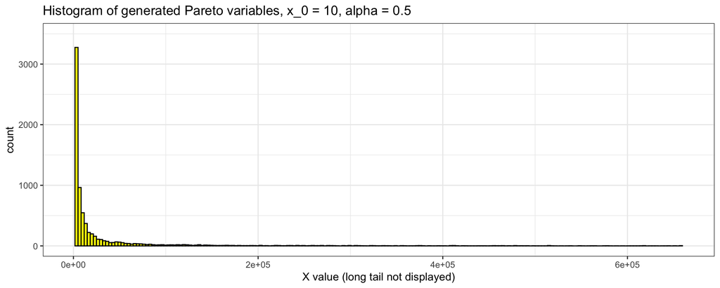

```r
## Simulate uniform random number on [0,1]
set.seed(1)
u <- runif(100000)

## Let alpha = 0.5, x_0 = 10
x_0 <- 10
alpha <- 0.5
x <- x_0/((1 - u)^(1/alpha))
x[x < x_0] <- NA
plt.df <- data.frame(x = x)

## Plot with ggplot2
library(ggplot2)
ggplot(plt.df) +
   geom_histogram(aes(x = x),
                  bins = 200, fill = "yellow", color = "black") +
  scale_x_continuous(limits = c(0, 661221.1)) +   ## limit X-axis
  scale_y_continuous(limits = c(0, 3500)) +       ## limit Y-axis
  labs(x = "X value (long tail not displayed)",
       title = "Histogram of generated Pareto variables, x_0 = 10, alpha = 0.5") +
  theme_bw()
```

##### (d)

$$S \left( x ; x _ { 0 } , \alpha \right) = 1 - F ( x ; x _ { 0 } , \alpha ) = \left( \frac { x _ { 0 } } { x } \right) ^ { \alpha }$$
$$S \left( 10;2,1 \right) = \left( \frac { 2 } { 10 } \right) ^ { 1 } = 0.2$$
Therefore 20% of the parts survive past $10$ years with these parameters.

##### (e)

We denote $x_{p}$ as the $p$-th quantile of the density. We solved for $x$ in (c) and we have
$$x_{p} = \frac { x _ { 0 } } { ( 1 - p ) ^ { \frac { 1 } { \alpha } } }$$
$$x_{0.8} = \frac { 2} { ( 1 - 0.8 ) ^ { \frac { 1 } { 1} } } = \frac{2}{0.2} = 10$$
Interpretation as in (d): $80$-th percentile is 10 years, that is, 20% of the parts will survive past $10$ years with these parameters.

### HW1 - Problem 8

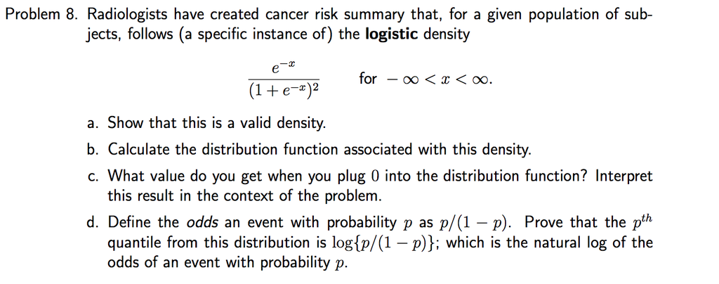

##### (a)

For all it holds $x \in \mathbb{R}$, $e^x > 0$, so we know that the function is positive. Let $u = e^{−x}$. Then we have $du = -e^{-x} dx$ and
$$\int _ { - \infty } ^ { \infty } \frac { e ^ { - x } } { \left( 1 + e ^ { - x } \right) ^ { 2 } } d x
= \int _ { \infty } ^ { 0 } \frac { u } { ( 1 + u ) ^ { 2 } }\left( - \frac{1}{u}\right)du
= \int _ { 0 } ^ { \infty } \frac { 1 } { ( 1 + u ) ^ { 2 } } d u \\
= - \left. \frac { 1 } { 1 + u } \right| _ { 0 } ^ { \infty } \\
= - \left. \frac { 1 } { 1 + e ^ { - x } } \right| _ { \infty } ^ { - \infty } \\
= \left. \frac { 1 } { 1 + e ^ { - x } } \right| _ { - \infty } ^ { \infty } \\
= \frac { 1 } { 1 + e ^ { - \infty } } - \frac { 1 } { 1 + e ^ { - (-\infty) } } \text{ (notation abuse)}\\
= \frac { 1 } { 1 + 0 } - \frac { 1 } { 1 + \infty } \text{ (notation abuse)}\\
= 1 - 0 = 1.$$

##### (b)

From above, we see that

$$F ( y ) = \int _ { - \infty } ^ { y } \frac { e ^ { - x } } { \left( 1 + e ^ { - x } \right) ^ { 2 } } d x
= \left. \frac { 1 } { 1 + e ^ { - x } } \right| _ { - \infty } ^ { y }
= \frac { 1 } { 1 + e ^ { - y } }$$

##### (c)

$F ( 0 ) = \frac { 1 } { 1 + e ^ { 0 } } = \frac { 1 } { 2 }$, therefore $0$ is the median of the distribution. Therefore the median cancer risk is $0$.

##### (d)

To find the $p$th quantile, we want to find the value $x$ such that $F(x) = p$.

Solving for $x$, we have
$$\begin{align*}
\frac{1}{1 + e^{-x}} = p
&\implies 1 + e^{-x} = \frac{1}{p} \\
& \implies e^{-x} = \frac{1}{p} - 1 \\
& \implies e^{-x} = \frac{1-p}{p} \\
& \implies -x = \log \left( \frac{1-p}{p}\right) \\
&\implies x = - \log \left( \frac{1-p}{p}\right) \\
& \implies x = \log \left( \frac{p}{1-p}\right)
\end{align*}$$

### `ggplot2` package

- In R, basic plots can be made using base R functions (we used so far: `hist()`, `plot()`, `qqnorm()`)
- `ggplot2` package allows to make more advanced plots:
  - multiple objects (i.e. multiple histograms),
  - multiple layers (point + line + shade + …),
  - customized plot labels (change font family, rotate labes),
  - multiple panel plots,
  - ploting map countours and marking points / lines / shapes on it,
  - much more (most beautiful ggplot).

#### `ggplot2` plot data input: Data Frame

`ggplot2` takes an input a Data Frame object (`?data.frame`).

- A data frame can be thought of a table, or a two-dimensional structure in which each column contains values of one variable and each row contains one observation (observation := one set of values from each column).
- Example: Data frame with 1 variable

```r
# Simulate 1000 variables
set.seed(123)
U = runif(1000, min = 0, max = 1)
X = rnorm(1000, mean = 0, sd = 1)

df1 <- data.frame(U)
dim(df1) # Get number of rows (observations), number of columns (variables)
```

```
## [1] 1000    1
```

```r
head(df1) # Look up first few rows of Data frame
```

```
##           U
## 1 0.2875775
## 2 0.7883051
## 3 0.4089769
## 4 0.8830174
## 5 0.9404673
## 6 0.0455565
```

- Example: Data frame with 2 variables

```r
df2 <- data.frame(U, X)
dim(df2) # Get number of rows (observations), number of columns (variables)
```

```
## [1] 1000    2
```

```r
head(df2) # Look up first few rows of Data frame
```

```
##           U           X
## 1 0.2875775 -0.60189285
## 2 0.7883051 -0.99369859
## 3 0.4089769  1.02678506
## 4 0.8830174  0.75106130
## 5 0.9404673 -1.50916654
## 6 0.0455565 -0.09514745
```

##### Operations on Data Frame

- `data.frame` is a basic `R` structure for working with data tables
- Plenty of operations one can do with `data.frame` object:
  - subset columns, subset rows
  - filter observations
  - mutate (construct and add new variables)
  - aggregate
- `dplyr` is perhaps most popular package for `data.frame` operations. See package website https://cran.r-project.org/web/packages/dplyr/ for references to tutorials (vignettes) on how to use `dplyr`

  _ Example: [Introduction to dplyr](https://cran.r-project.org/web/packages/dplyr/vignettes/dplyr.html)

#### `ggplot2` plot arguments. Example: histogram

- `ggplot()` takes a data frame as the first argument and an aesthetic mapping (`aes()`) as the second argument.
- Multiple layers and/or formatting function can be added to `ggplot()`.
- Example: Histogram of X variable values

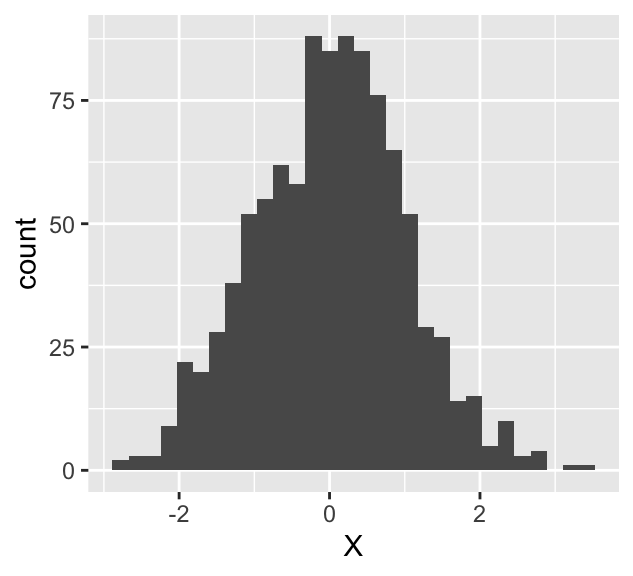

```r
#install.packages("ggplot2")
library(ggplot2)
plt1_base <- ggplot(df2, aes(x = X))
plt1_base + geom_histogram()
```

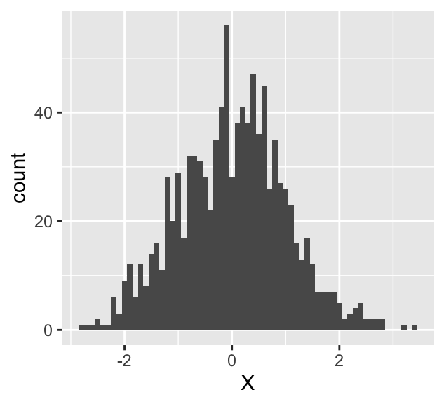

```r
plt1_base + geom_histogram(binwidth = 0.1)
```

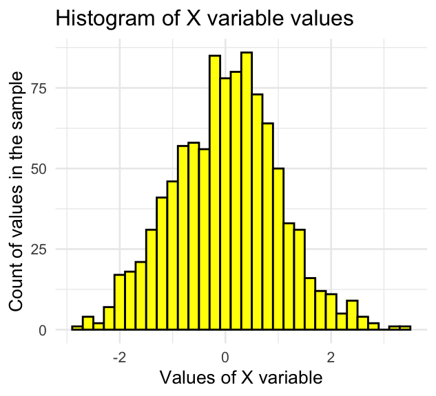

```r
plt1_base +
  geom_histogram(binwidth = 0.2, color = "black", fill = "yellow") +
  theme_minimal(base_size = 10) +
  labs(x = "Values of X variable", y = "Count of values in the sample",
       title = "Histogram of X variable values")
```

#### Tidy data

Table of a form of “tidy data”:

1. Each variable forms a column.
2. Each observation forms a row.

Example of tidy data:

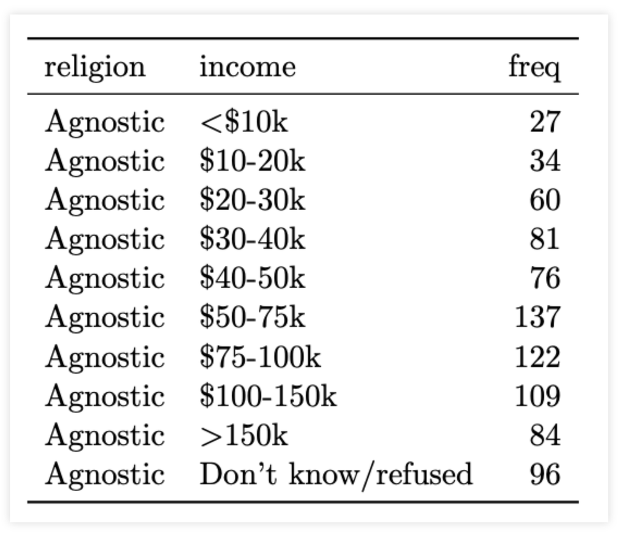

Example of NOT tidy data (Column headers are values, not variable names):

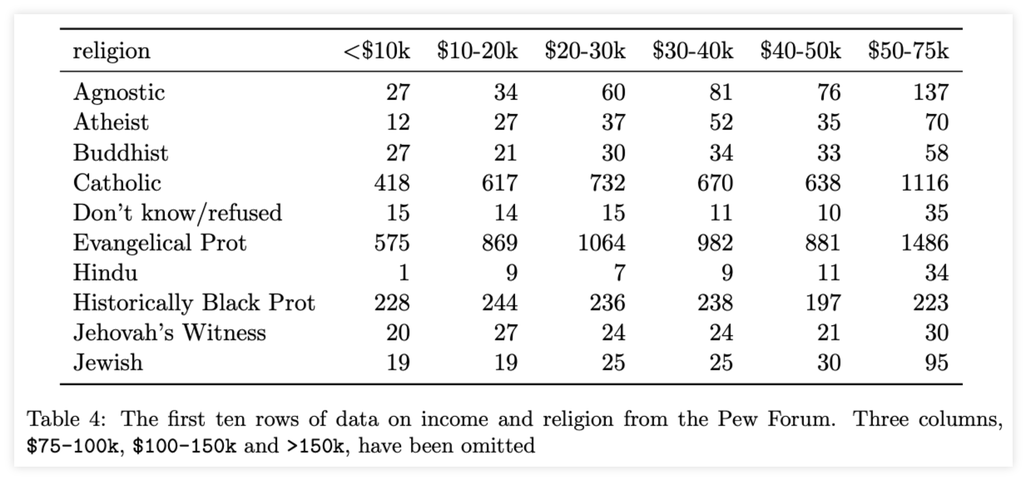

#### Example: histogram (plot two variables simultaneously)

- `melt()` function from `reshape2` package allows to transform Data Frame into a “tidy data” form.

```r
library(reshape2)
head(df2)
```

```
##           U           X
## 1 0.2875775 -0.60189285
## 2 0.7883051 -0.99369859
## 3 0.4089769  1.02678506
## 4 0.8830174  0.75106130
## 5 0.9404673 -1.50916654
## 6 0.0455565 -0.09514745
```

```r
## transform df2 into a "tidy data" form
df2_long <- melt(df2)
head(df2_long)
```

```
##   variable     value
## 1        U 0.2875775
## 2        U 0.7883051
## 3        U 0.4089769
## 4        U 0.8830174
## 5        U 0.9404673
## 6        U 0.0455565
```

```r
tail(df2_long)
```

```
##      variable      value
## 1995        X -1.0933008
## 1996        X  0.2144794
## 1997        X  0.8925711
## 1998        X  1.0187580
## 1999        X  1.0891120
## 2000        X -0.1631290
```

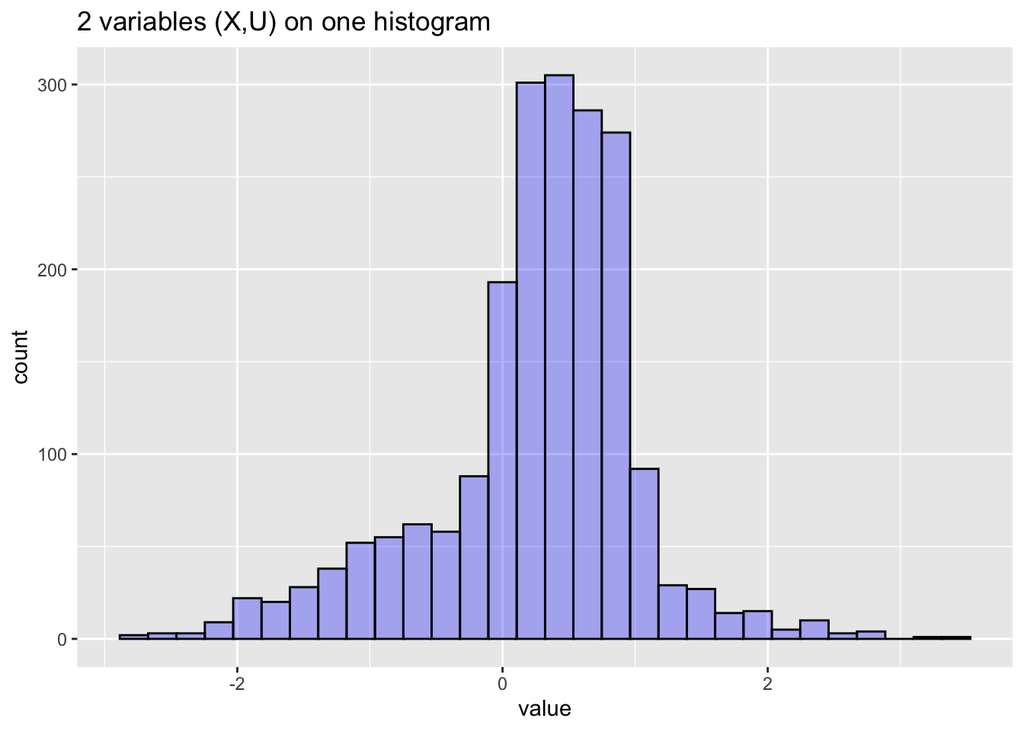

```r
## Use ggplot2 to plot mutiple histograms on the same plot
plt2_base <- ggplot(df2_long, aes(x = value))
plt2_base +
  geom_histogram(color = "black", fill = "blue", alpha = 0.3) +
  labs(title = "2 variables (X,U) on one histogram")
```

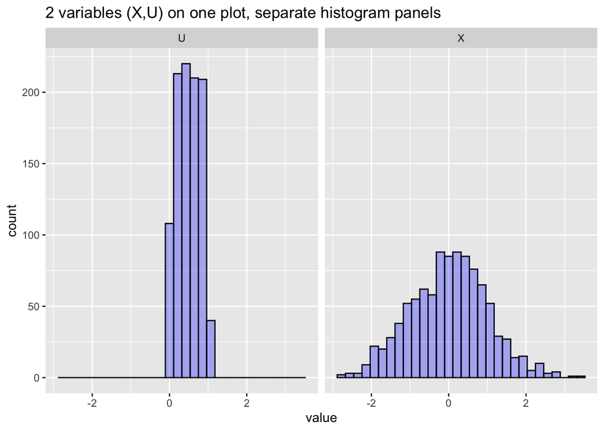

```r
plt2_base +
  geom_histogram(color = "black", fill = "blue", alpha = 0.3) +
  facet_wrap(~ variable) +
  labs(title = "2 variables (X,U) on one plot, separate histogram panels")
```

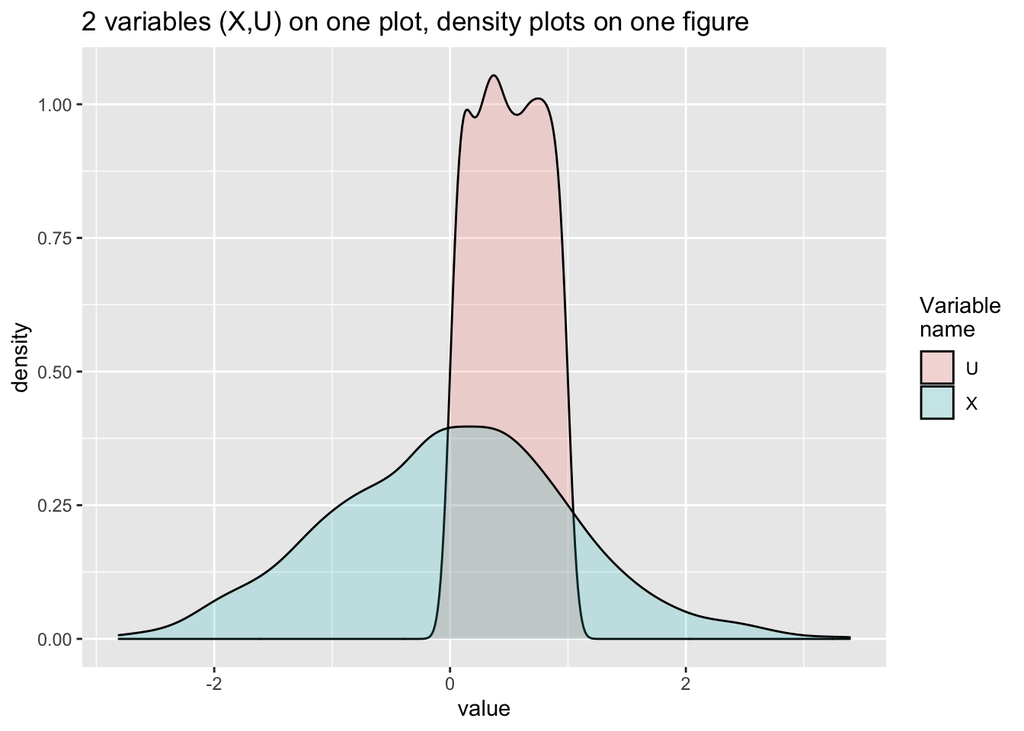

```r
plt3_base <- ggplot(df2_long, aes(x = value, fill = variable))
plt3_base + geom_density(alpha = 0.2) +
  labs(title = "2 variables (X,U) on one plot, density plots on one figure",
       fill = "Variable\nname")
```

#### Example: gamma densities plot from HW1 - Problem 12

`ggplot2` version:

```r
# Recall this part:
x <- seq(from = 0, to = 15, by = 0.01)
y1 <- dgamma(x, shape=1, scale=1)
y2 <- dgamma(x, shape=2, scale=1)
y3 <- dgamma(x, shape=3, scale=1)
y4 <- dgamma(x, shape=2, scale=2)
y5 <- dgamma(x, shape=2, scale=0.5)

# For ggplot2 plotting:
x_length <- length(x)
plot_df <- data.frame(x, y1, y2, y3, y4, y5)
plot_df_melted <- melt(plot_df, id.vars = "x")
head(plot_df)
```

```
##      x        y1          y2           y3          y4         y5
## 1 0.00 1.0000000 0.000000000 0.000000e+00 0.000000000 0.00000000
## 2 0.01 0.9900498 0.009900498 4.950249e-05 0.002487531 0.03920795
## 3 0.02 0.9801987 0.019603973 1.960397e-04 0.004950249 0.07686316
## 4 0.03 0.9704455 0.029113366 4.367005e-04 0.007388340 0.11301174
## 5 0.04 0.9607894 0.038431578 7.686316e-04 0.009801987 0.14769862
## 6 0.05 0.9512294 0.047561471 1.189037e-03 0.012191374 0.18096748
```

```r
head(plot_df_melted)
```

```
##      x variable     value
## 1 0.00       y1 1.0000000
## 2 0.01       y1 0.9900498
## 3 0.02       y1 0.9801987
## 4 0.03       y1 0.9704455
## 5 0.04       y1 0.9607894
## 6 0.05       y1 0.9512294
```

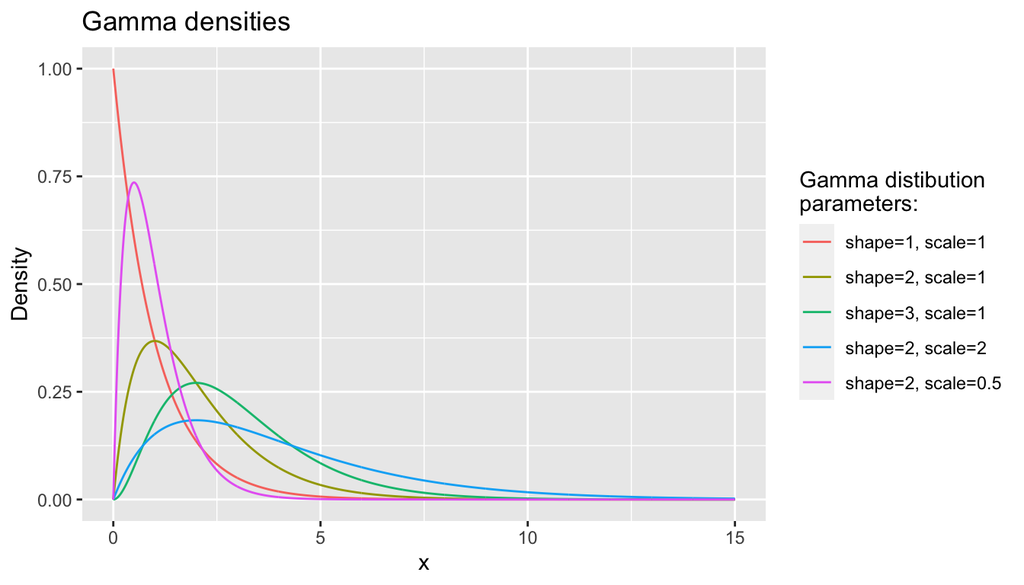

```r
## Change lables for y1, y2, y3, y4, y5
plot_df_melted$variable <-
  factor(as.character(plot_df_melted$variable),
         levels = c("y1", "y2", "y3", "y4", "y5"),
         labels = c("shape=1, scale=1", "shape=2, scale=1",
                    "shape=3, scale=1", "shape=2, scale=2",
                    "shape=2, scale=0.5"))

ggplot(plot_df_melted, aes(x = x, y = value, group = variable, color = variable)) +
  geom_line() +
  labs(x = "x", y = "Density", title = "Gamma densities", color = "Gamma distibution\nparameters:")
```